# Introduction to Quarto

workshops

collaboration

Author

Darren Shoemaker

Published

November 20, 2026

**Note**

This is a reproduction of an introductory workshop on the Quarto ecosystem I gave during a lab meeting in the [Krabbenhoft Aquatic Ecology lab](https://coreykrabbenhoft.com/).<sup>1</sup>

## What is Quarto?

Quarto is a popular free and open-source (FOSS) technical publishing system used to create dynamic reports, dashboards, articles, presentations, books, and even websites.<sup>2</sup> If you have worked in R for any length of time, you’ve almost certainly encountered Quarto content, even if you didn’t notice. Quarto is most commonly used alongside R, Python, and Julia, but supports an astonishing variety of coding languages and document formats. Quarto takes generic Markdown text as an input and renders a document in the desired format.

Because Quarto can do so many different things, the system can appear overwhelming. For those who learned programming languages such as R, Python, or Git, you likely remember particularly painful learning curves. Quarto is not like that! In fact, learning basic Quarto is refreshingly simple.

For this workshop, we’re mostly going to focus on using Quarto to produce reports, typically in the context of academic collaborations. Imagine you’re trying to share a statistical analysis in R with your advisor, graduate committee, or coauthors. Quarto can do a lot, but we want to keep things simple for now.

We will cover the three primary components of Quarto: the header, the markdown, and code chunks, and rendering your final document.

## Getting Started

### Checking Your Installation

First, we need to check if we have Quarto installed. Open the terminal and type or copy the following command:

```bash
quarto --version
```

If Quarto is installed, you should see a version number like `1.9.38`. Quarto comes bundled with Positron and RStudio, so you likely already have it even if you haven’t used it.

If you don’t have Quarto installed, you can find the executable for your operating system from the [Quarto website](https://quarto.org/docs/get-started/) or install from the command line.

**Windows**

```bash
winget install Posit.Quarto
```

**macOS**

```bash
brew install --cask quarto
```

### Creating a New Document

Staying organized is just as important for Quarto as any other file type. I recommend creating a new folder to keep all of your content in one place for this workshop. If you work in RStudio, you can create a new R Project with a .Rproj file to mark the working directory. If you are working in VSCode or Positron, you can just create a new folder.

Quarto files use the `.qmd` extension. To create your Quarto document, create a new file with a creative name, such as `quarto_workshop.qmd`. RStudio has an option in the new file dropdown to create a new Quarto document, which will pre-populate the document with some “helpful” defaults. If you are working in Positron, your file will be blank.

## Anatomy of a Quarto Document

### The YAML Header

Quarto documents are primarily defined by metadata included in a YAML header, which you might sometimes see referred to as frontmatter. This header includes important information about the document and sets rules for how different components will behave.

There are hundreds of possible combinations of these rules you could include, so for this workshop we’re only going to focus on what I think are the most immediately relevant. With that in mind, there are a few critical points I want you to remember:

1. Every Quarto document must have a YAML header!
2. Beyond the most basic formatting rules, these are mostly not worth committing to memory! Save your mental energy for ecological and statistical concepts that demand real understanding. You’ll learn what’s important out of habit.
3. Spaces in a YAML header mean something! If a document is not rendering correctly, you almost certainly have an incorrect space somewhere.

Here is a basic example YAML header:

```yaml
---
title: "Creative Title"
author: "Give Yourself the Credit You Deserve"
date: today
format: html
embed-resources: true
---
```

Your YAML header is marked by three hyphens (`---`). Each line inside describes a different rule for the document. In my opinion, `title`, `author`, `date`, and `format` are the most important. The title, author, and date appear at the top of the document after rendering.

You can type out a date if you want, for example, to pretend you didn’t make your document at the last minute, but you can also just use `today` to automatically populate the field with the date you saved the document.

The default output format for a Quarto document is `html`, so this field is also not strictly necessary. However, you may wish to change or add additional formats down the road, so I recommend getting used to including this.

I personally recommend always setting `embed-resources: true` as well. If you are using images, external fonts, a custom theme, or so on, this ensures they are stored with the document, which is useful for sharing. It’s annoying to share a document and realize all of the images are broken.

The YAML header for this document includes a few extra fields:

```yaml
---
title: "Introduction to Quarto"
author: "Darren Shoemaker"
date: today
categories:
format:
  html:
    toc: true
    toc-depth: 3
    code-copy: true
embed-resources: true
---
```

- `toc` (table of contents) is another field I find myself using often. This automatically adds a table of contents to an HTML document, which can be really helpful for helping collaborators navigate your report.
- `toc-depth` defines the level of headers that are included in the table of contents. You can tweak this depending on how long your document ends up and how many subheadings you end up using.
- `code-copy` adds a copy button to code chunks, just like the ones on this page. This can be useful if you want others to be able to follow along with an analysis, saving them typing and likely preventing errors.

### The Text Body

I think the most compelling reason to use Quarto is the ability to seamlessly integrate plain text, code, and analysis outputs including graphs and tables. This makes it easy to share your work with collaborators, even those who may not know R!

In practice, I find this commonly looks like a header defining a major section of an analysis, such as “Data Cleaning,” “Summary Statistics,” or “Visualizations,” followed by the relevant code chunk, and finally a plain text interpretation explaining what you think the output means.

Any text written directly in a Quarto document is interpreted as plain text. Use `#`s to add headers, which will also show up in the table of contents.

| Header Level | Syntax | Example |
| --- | --- | --- |
| Level 1 | `#` | `# Heading Level 1 (Largest)` |
| Level 2 | `##` | `## Heading Level 2` |
| Level 3 | `###` | `### Heading Level 3` |
| Level 4 | `####` | `#### Heading Level 4` |
| Level 5 | `#####` | `##### Heading Level 5` |
| Level 6 | `######` | `###### Heading Level 6 (Smallest)` |

### Code Chunks

Code chunks are the “dynamic” component of a Quarto document. To add a code chunk, type three backticks (`` ``` ``), followed by brackets `{}`, and add three more backticks on a new line. Everything in between the two sets of backticks is interpreted as code. You can define the coding language you’re using by typing it inside the brackets, such as `{r}`. In RStudio and Positron, use the keyboard shortcut `ctrl+alt+i` to automatically insert an R code chunk.

For example, we’re going to use the classic “iris” dataset from Ronald Fisher. We will load the data, inspect the dataframe with `head()`, plot flower petal lengths and widths by species, and finally add a legend.

```r
data(iris)

head(iris)
```

```
  Sepal.Length Sepal.Width Petal.Length Petal.Width Species
1          5.1         3.5          1.4         0.2  setosa
2          4.9         3.0          1.4         0.2  setosa
3          4.7         3.2          1.3         0.2  setosa
4          4.6         3.1          1.5         0.2  setosa
5          5.0         3.6          1.4         0.2  setosa
6          5.4         3.9          1.7         0.4  setosa
```

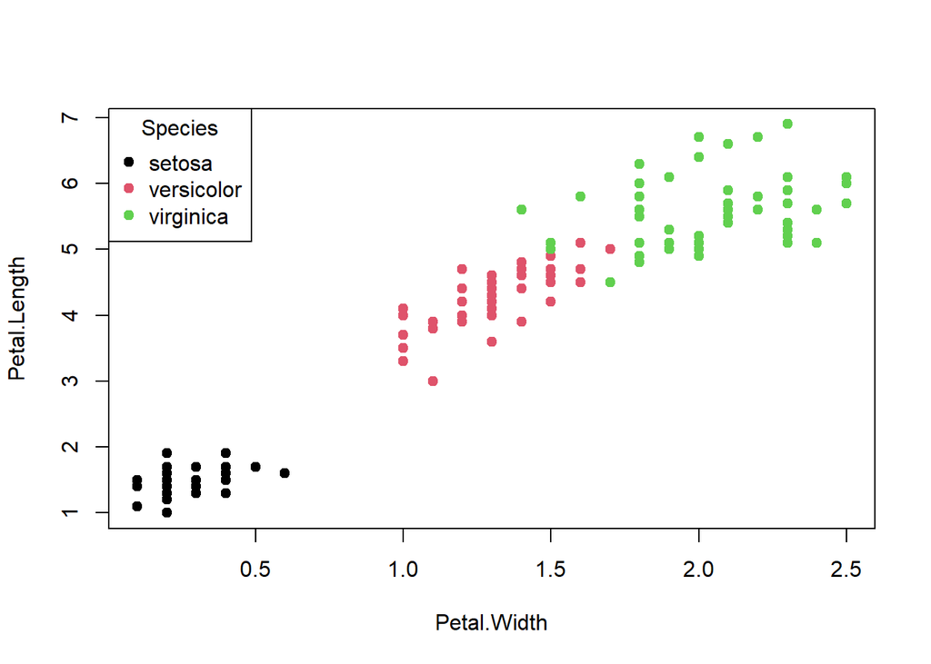

```r
plot(Petal.Length ~ Petal.Width, col = Species, data = iris, pch = 19)

legend(
  x = "topleft",
  legend = levels(iris$Species),
  col = 1:3,
  pch = 19,
  title = "Species"
)
```

Looks like *virginica* has the largest flowers. Who would have guessed?

Here is where I think the real strength of Quarto shines through. Imagine instead of the iris dataset, you instead needed to share the outcome of an analysis with your dissertation committee. You now your actual code, your figures and plots, and your interpretation. This means you can show your code to the collaborators who want to see it, and your interpretations to those who may not care about the nuance, all in one document!

### Code Chunk Options

Just like the YAML header at the top of the document, you can also set options for individual code chunks. These have to appear at the top of the code chunk, and are marked with a `#` followed by a vertical bar `|`. These are useful if you want to modify the output of one code chunk without applying the options to every code chunk.

#### Warnings

The following code intentionally produces a warning because we’re taking the log of values that include non-positive numbers:

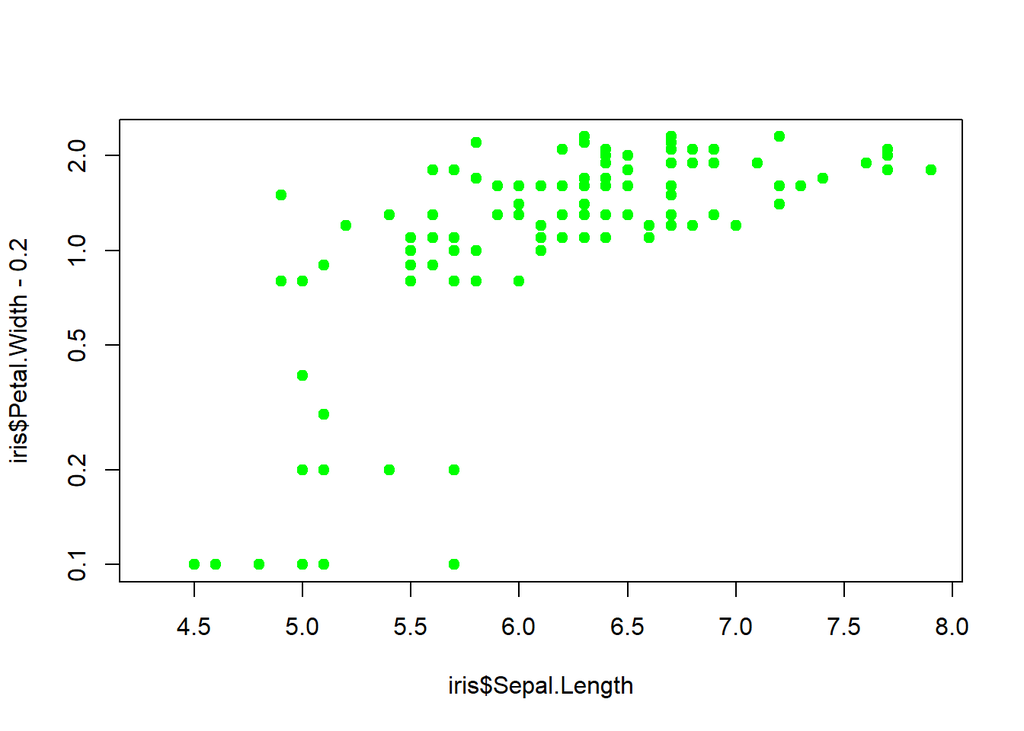

```r
# This plot intentionally produces a warning due to log transformation of non-positive values
plot(iris$Sepal.Length, iris$Petal.Width - 0.2, log = "y", col = 'green', pch = 19)
```

[output not shown]

In this case, the warning is important. R will drop non-positive values prior to the log transformation, which means we end up losing data points on the plot. However, what if the warning is not important? We can hide warnings by adding `#| warning: false` to the top of the code chunk.

#### Eval

One of the drawbacks to Quarto is each code chunk has to be *evaluated*, or run, each time the document is rendered. This takes less than a second for this document, which is just base R plots and some text, but can be slow with real statistical analyses. Another useful option is `#| eval: false`, which keeps the code chunk in the document, but does not actually run it.

```r
# This code chunk will appear in the document but will not be executed
plot(iris$Sepal.Length, iris$Petal.Width - 0.2, log = "y", col = 'green', pch = 19)
```

Here, the code still appears, but because R did not actually run the line, neither the plot nor the warning are included.

#### Echo

If you want to hide the code completely, you can use `#| echo: false`. “echo” means “repeat” or “include,” so marking this option as false just means not including the code in the document.

```
Warning in xy.coords(x, y, xlabel, ylabel, log): 34 y values <= 0 omitted from
logarithmic plot
```

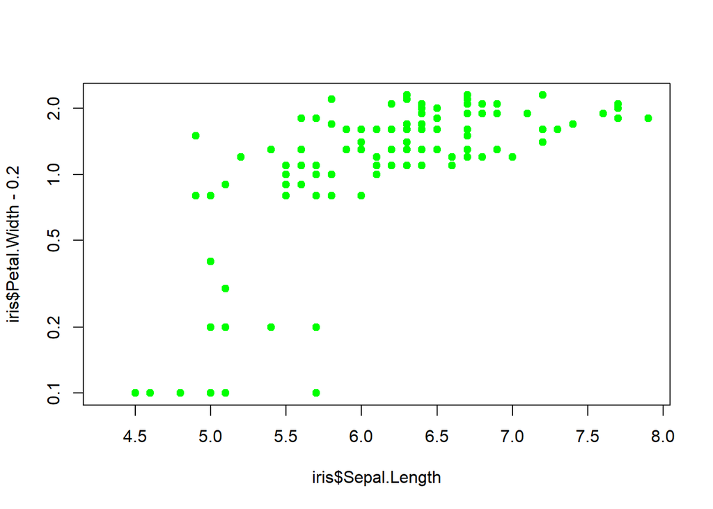

Note the code chunk doesn’t appear, but the warning and plot still show up. What gives? We set `#| echo: false`, but we did not set `#| eval: false`, so the code still executed and produced an output.

#### Output

If we want to show and run the code, but hide the output, we can use `#| output: false`. I don’t use this one often, but if the output of a code chunk is especially messy, this can be helpful.

```r
# The code will run and produce a plot, but the text output will be hidden
plot(iris$Sepal.Length, iris$Petal.Width - 0.2, log = "y", col = 'green', pch = 19)
```

#### Include

Finally, you can set `#| include: false` if you have code that you want to run, but hide both the output and code chunks. Typically this is used to hide libraries and other setup information, but for most of my use cases I want to make it clear what libraries I use, so I don’t use this often either.

As with the YAML headers, there are many other options for code chunks. These are just a small sample of ones you’ll use frequently.

## Rendering Your Report

Once you have all the content you want to include, it’s time to render the document. If you set `format: html` or did not specify the format, rendering the document will produce a `.html` file with the same name as your report.

Both RStudio and Positron have a checkbox on the upper left of the script window that says “render on save.” This is fine for our simple example, but there are a few points of caution. If you save often, this will re-render the document every time you save. Because saving frequently is best practice (your dog might unplug your computer), this can bog down your computer for highly complex documents that take a long time to render.

Personally, I recommend rendering from the terminal instead. When you are ready to finalize your document, enter the following command into the terminal:

```bash
quarto render
```

This will render the document in the desired format, but you won’t have to re-render more times than necessary.

Using the terminal is also best practice if you want to render multiple formats at once. Positron has a quirk where using the render button directly in the IDE will only render one of the formats. For example, if I decided I wanted both an HTML and a PDF document, such as:

```yaml
---
title: "Introduction to Quarto"
author: "Darren Shoemaker"
format:
  html:
  pdf:
---
```

Only the HTML document would be created. This behavior is inconsistent and annoying, but rendering from the terminal always works, so I think this is just best practice.

Once you have the document, you’re done! Share your document just as you would any other. You may not be used to `.html` files, but these open in any web browser.

## Beyond the Basics

That’s all we’re going to cover today, but Quarto is highly extensible, so if there’s more you want to explore, I recommend digging into the official documentation or just a simple web search.

## References

1. Krabbenhoft, C. *Krabbenhoft Aquatic Ecology Lab*. https://coreykrabbenhoft.com/. Accessed November 20, 2026.
2. Posit, Inc. *Quarto Documentation*. https://quarto.org/docs/. Accessed November 20, 2026.